# Module 9 - Poisson Regression

## Data and Description

The Federal Highway Administration (FHWA) conducts research in an effort to improve road safety. In these research efforts, the FHWA collects data on the location of crashes along with characteristics of a given road. Knowing the location of accidents on a road can help the FHWA determine which segments of a road are dangerous (i.e. so called “hot spots”). Additionally, characteristics of the road give insight into why the crash happened. For example, if a section of the road containing strong curvature has a high rate of crashes, the FHWA can suggest safety improvements to that particular section of road in an effort to reduce the number of crashes.

The purpose of this analysis is to regress the number of car crashes on segments of a road onto variables such as road characteristics (type of pavement, shoulder width, number of lanes, etc.) and annual average daily traffic. The ultimate goal of this modeling is to be able to identify road characteristics that lead to increased number of accidents. Data was collected for a random set of 207 road segments in Minnesota, and here is a description of the variables:

| Variable | Description |
| --- | --- |
| AADT | Average annual daily traffic |
| MEDWID | Median width in feet, one of three values: >30, 1-30, VR |
| MED_TYPE | Median type, one of two values: Barrier, No Barrier |
| LSHLDWID | Left shoulder width in feet, one of two values: <=4 feet, > 4 feet |
| LSHL_TYP | Left shoulder type, one of two values: Bitum Conc, Other |
| SURF_WID | Surface width in feet, one of two values: <=24 feet, > 24 feet |
| RSHLDWID | Right shoulder width in feet, one of two values: 10 feet, 8 feet |
| RSHL_TYP | Right shoulder type, one of two values: Bitum Conc, Other |
| NO_LANES | Total number of lanes, one of two values: > 4 lanes, 4 lanes |
| LANEWID | Lane width, one of two values: > 12 feet, 12 feet |
| RODWYCLS | Roadway class, one of two values: Rural, Urban |
| TOTALCRASHES | Total number of crashes per segment |

Do the following:

1. Download the “HSIS.csv” file from Canvas and put it in the same folder as this R Markdown file.
2. Read in the data set, call it “crash”, and take a look at the top few rows.

```r
crash <- read.csv("HSIS.csv", header = TRUE)
head(crash)
```

```
##    AADT MEDWID   MED_TYPE  LSHLDWID LSHL_TYP  SURF_WID RSHLDWID RSHL_TYP
## 1 20850     VR No Barrier <= 4 feet    Other > 24 feet  10 feet    Other
## 2 20700     VR No Barrier <= 4 feet    Other > 24 feet  10 feet    Other
## 3 20700     VR No Barrier <= 4 feet    Other > 24 feet  10 feet    Other
## 4 20700     VR No Barrier <= 4 feet    Other > 24 feet  10 feet    Other
## 5 20700     VR No Barrier <= 4 feet    Other > 24 feet  10 feet    Other
## 6 20700     VR No Barrier <= 4 feet    Other > 24 feet  10 feet    Other
##   NO_LANES   LANEWID RODWYCLS TOTALCRASHES
## 1  4 lanes > 12 feet    Rural           10
## 2  4 lanes > 12 feet    Rural            6
## 3  4 lanes > 12 feet    Rural            0
## 4  4 lanes > 12 feet    Rural            2
## 5  4 lanes > 12 feet    Rural            4
## 6  4 lanes > 12 feet    Urban            1
```

## Explore the data. Create a histogram for TOTALCRASHES.

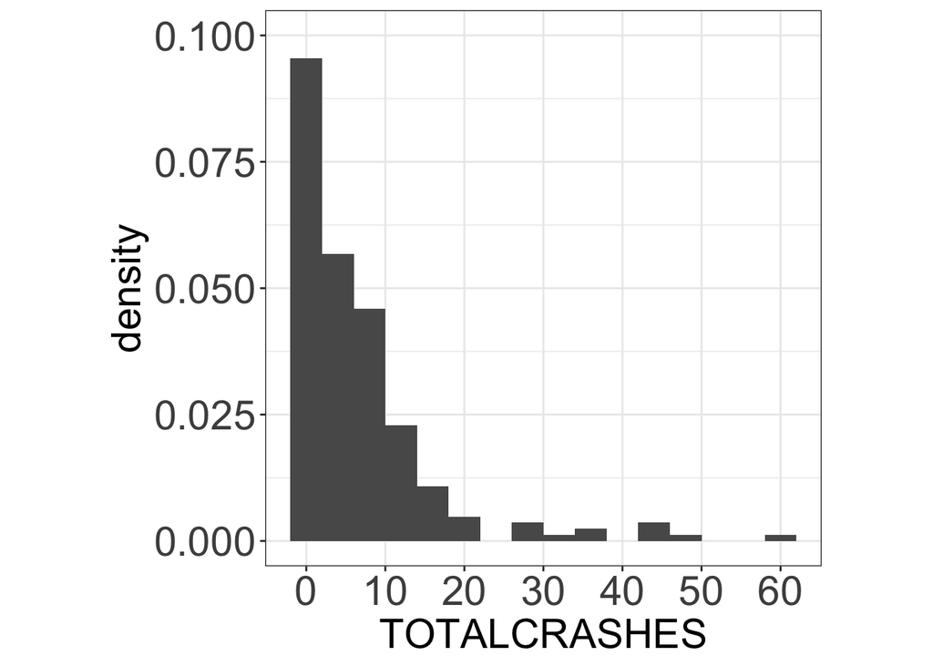

```r
# Histogram for TOTALCRASHES
ggplot(data = crash, mapping = aes(x = TOTALCRASHES)) +
  geom_histogram(mapping = aes(y = ..density..), binwidth = 4) +
  theme_bw() +
  scale_x_continuous(labels = seq(0, 60, by = 10),
                     breaks = seq(0, 60, by = 10),
                     minor_breaks = seq(0, 60, by = 10)) +
  scale_y_continuous(limits = c(0, 0.1)) +
  theme(axis.title.x = element_text(size = sz),
        axis.title.y = element_text(size = sz),
        axis.text = element_text(size = sz),
        aspect.ratio = 1)
```

## Use backward model selection with BIC to choose a subset of the predictors to use in the model. You will first need to fit the Poisson regression model with all predictors, using the function `glm` with the additional argument `family = poisson(link = 'log')`. Then use `stepAIC` in the same way you did for linear regression.

```r
crash.full <- glm(TOTALCRASHES ~ ., data = crash, family = poisson(link = 'log'))

crash.bwd <- stepAIC(crash.full, direction = 'backward', k = log(nrow(crash)))
```

```
## Start:  AIC=2338.61
## TOTALCRASHES ~ AADT + MEDWID + MED_TYPE + LSHLDWID + LSHL_TYP +
##     SURF_WID + RSHLDWID + RSHL_TYP + NO_LANES + LANEWID + RODWYCLS
##
##            Df Deviance    AIC
## - RSHLDWID  1   1646.3 2333.7
## - SURF_WID  1   1646.8 2334.2
## - LSHLDWID  1   1647.6 2335.0
## - LSHL_TYP  1   1648.7 2336.1
## - LANEWID   1   1648.8 2336.2
## - RSHL_TYP  1   1649.5 2336.9
## - NO_LANES  1   1649.5 2336.9
## <none>          1645.9 2338.6
## - MED_TYPE  1   1659.8 2347.2
## - MEDWID    2   1688.5 2370.5
## - RODWYCLS  1   1734.5 2421.8
## - AADT      1   1759.5 2446.8
##
## Step:  AIC=2333.67
## TOTALCRASHES ~ AADT + MEDWID + MED_TYPE + LSHLDWID + LSHL_TYP +
##     SURF_WID + RSHL_TYP + NO_LANES + LANEWID + RODWYCLS
##
##            Df Deviance    AIC
## - SURF_WID  1   1647.1 2329.2
## - LSHLDWID  1   1647.8 2329.8
## - LANEWID   1   1648.8 2330.9
## - LSHL_TYP  1   1649.1 2331.1
## - RSHL_TYP  1   1649.8 2331.9
## - NO_LANES  1   1649.9 2332.0
## <none>          1646.3 2333.7
## - MED_TYPE  1   1660.0 2342.0
## - MEDWID    2   1690.3 2367.0
## - RODWYCLS  1   1740.5 2422.5
## - AADT      1   1759.5 2441.5
##
## Step:  AIC=2329.17
## TOTALCRASHES ~ AADT + MEDWID + MED_TYPE + LSHLDWID + LSHL_TYP +
##     RSHL_TYP + NO_LANES + LANEWID + RODWYCLS
##
##            Df Deviance    AIC
```

[output cut: 37 more lines]

```
## - RODWYCLS  1   1750.4 2416.4
## - AADT      1   1765.5 2431.5
##
## Step:  AIC=2321.95
## TOTALCRASHES ~ AADT + MEDWID + MED_TYPE + NO_LANES + LANEWID +
##     RODWYCLS
##
##            Df Deviance    AIC
## <none>          1655.9 2321.9
## - NO_LANES  1   1669.8 2330.5
## - LANEWID   1   1672.6 2333.3
## - MED_TYPE  1   1672.9 2333.6
## - MEDWID    2   1714.4 2369.8
## - RODWYCLS  1   1758.0 2418.6
## - AADT      1   1777.2 2437.9
```

## Use the `glm` function to fit a Poisson regression model using the variables identified above. Note that you will need to include the following argument to the `glm` function to indicate you are performing Poisson regression: `family = poisson(link = "log")`. (The coefficients for AADT and RODWYCLS should match the ones on slides 21 and 22 in the notes.)

```r
crash.poisson <- glm(TOTALCRASHES ~ AADT + MEDWID + MED_TYPE + NO_LANES + LANEWID + RODWYCLS, data = crash, family = poisson)
summary(crash.poisson)
```

```
##
## Call:
## glm(formula = TOTALCRASHES ~ AADT + MEDWID + MED_TYPE + NO_LANES +
##     LANEWID + RODWYCLS, family = poisson, data = crash)
##
## Deviance Residuals:
##     Min       1Q   Median       3Q      Max
## -5.4569  -2.5275  -0.9581   1.0427  10.1278
##
## Coefficients:
##                      Estimate Std. Error z value Pr(>|z|)
## (Intercept)         3.870e-01  2.053e-01   1.885 0.059478 .
## AADT                2.474e-05  2.137e-06  11.579  < 2e-16 ***
## MEDWID1-30          4.185e-01  1.045e-01   4.006 6.17e-05 ***
## MEDWIDVR           -3.138e-01  5.706e-02  -5.499 3.82e-08 ***
## MED_TYPENo Barrier  5.762e-01  1.390e-01   4.144 3.41e-05 ***
## NO_LANES4 lanes     4.766e-01  1.320e-01   3.611 0.000305 ***
## LANEWID12 feet      2.465e-01  6.132e-02   4.019 5.84e-05 ***
## RODWYCLSUrban      -6.325e-01  6.372e-02  -9.926  < 2e-16 ***
## ---
## Signif. codes:  0 '***' 0.001 '**' 0.01 '*' 0.05 '.' 0.1 ' ' 1
##
## (Dispersion parameter for poisson family taken to be 1)
##
##     Null deviance: 1880.2  on 206  degrees of freedom
## Residual deviance: 1655.9  on 199  degrees of freedom
## AIC: 2295.3
##
## Number of Fisher Scoring iterations: 5
```

## Briefly, check that the link function is appropriate by plotting the log of the response against the systematic component estimates.

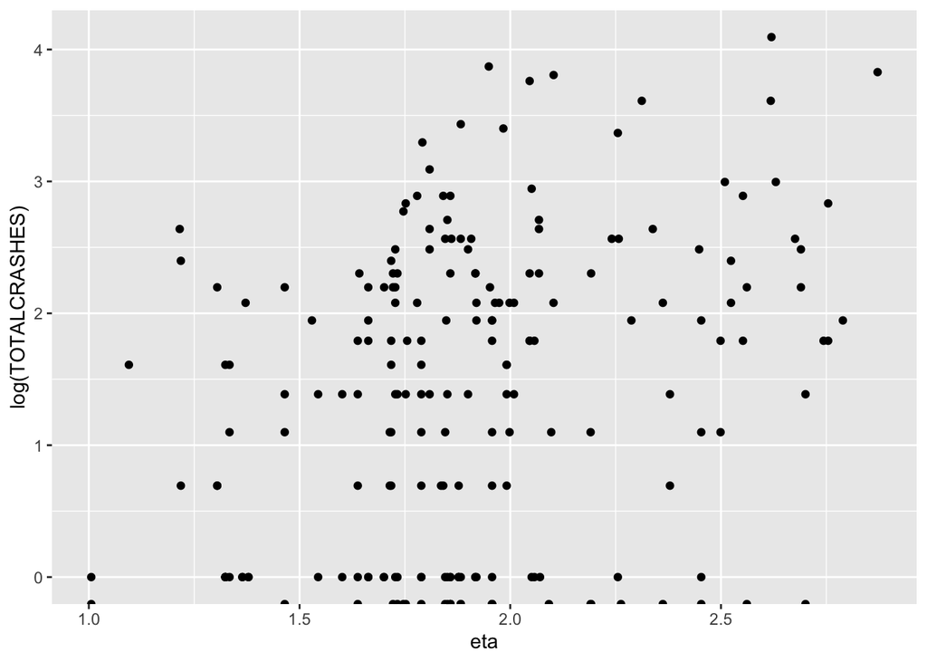

```r
# First, get the systematic component estimates
eta.hat <- predict(crash.poisson, type = 'link')

# Use ggplot to plot log(TOTALCRAHSES) against eta.hat - note that some of the values
# for TOTALCRASHES are 0, but ggplot will handle this for you

crash$eta <- eta.hat
ggplot(data = crash) + geom_point(aes(x = eta, y = log(TOTALCRASHES)))
```

## Compute Pearson’s $\chi^2$ value for this data set, and conduct the goodness-of-fit test. Do the data exhibit overdispersion? If so, refit the model using quasi-Poisson regression.

```r
Xsq <- sum(residuals(crash.poisson, type = 'pearson')^2)

# Use the pchisq function with the correct degrees of freedom to get the p-value
1 - pchisq(Xsq, df = nrow(crash) - 8)
```

```
## [1] 0
```

```r
# If necessary, refit the model using glm with family = quasipoisson
crash.qp <- glm(TOTALCRASHES ~  AADT + MEDWID + MED_TYPE + NO_LANES + LANEWID + RODWYCLS, data = crash, family = quasipoisson)
summary(crash.qp)
```

```
##
## Call:
## glm(formula = TOTALCRASHES ~ AADT + MEDWID + MED_TYPE + NO_LANES +
##     LANEWID + RODWYCLS, family = quasipoisson, data = crash)
##
## Deviance Residuals:
##     Min       1Q   Median       3Q      Max
## -5.4569  -2.5275  -0.9581   1.0427  10.1278
##
## Coefficients:
##                      Estimate Std. Error t value Pr(>|t|)
## (Intercept)         3.870e-01  6.502e-01   0.595 0.552433
## AADT                2.474e-05  6.767e-06   3.656 0.000328 ***
## MEDWID1-30          4.185e-01  3.308e-01   1.265 0.207338
## MEDWIDVR           -3.138e-01  1.807e-01  -1.736 0.084027 .
## MED_TYPENo Barrier  5.762e-01  4.402e-01   1.309 0.192134
## NO_LANES4 lanes     4.766e-01  4.180e-01   1.140 0.255574
## LANEWID12 feet      2.465e-01  1.942e-01   1.269 0.205879
## RODWYCLSUrban      -6.325e-01  2.018e-01  -3.134 0.001982 **
## ---
## Signif. codes:  0 '***' 0.001 '**' 0.01 '*' 0.05 '.' 0.1 ' ' 1
##
## (Dispersion parameter for quasipoisson family taken to be 10.02848)
##
##     Null deviance: 1880.2  on 206  degrees of freedom
## Residual deviance: 1655.9  on 199  degrees of freedom
## AIC: NA
##
## Number of Fisher Scoring iterations: 5
```

## Create 95% confidence intervals for $\beta_j$, $\exp\{\beta_j\}$, and $100 \times (\exp\{\beta_j\} - 1)%$ for all predictors using the `confint` function. Make sure you can interpret the intervals correctly.

```r
# hint: for the last two confidence intervals, you will just be transforming
# the values you get from confint (you will not be using different arguements
# to the function)

# Additive effect on the log-mean
CIeta <- confint(crash.qp, parm = 2:8)
round(CIeta, 2)
```

```
##                    2.5 % 97.5 %
## AADT                0.00   0.00
## MEDWID1-30         -0.28   1.03
## MEDWIDVR           -0.67   0.04
## MED_TYPENo Barrier -0.30   1.44
## NO_LANES4 lanes    -0.30   1.34
## LANEWID12 feet     -0.12   0.64
## RODWYCLSUrban      -1.03  -0.24
```

```r
# Multiplicative effect on the mean
round(exp(CIeta), 2)
```

```
##                    2.5 % 97.5 %
## AADT                1.00   1.00
## MEDWID1-30          0.76   2.80
## MEDWIDVR            0.51   1.04
## MED_TYPENo Barrier  0.74   4.24
## NO_LANES4 lanes     0.74   3.82
## LANEWID12 feet      0.88   1.89
## RODWYCLSUrban       0.36   0.79
```

```r
# Percentage effect on the mean
round(100*(exp(CIeta) - 1), 2)
```

```
##                     2.5 % 97.5 %
## AADT                 0.00   0.00
## MEDWID1-30         -24.31 180.08
## MEDWIDVR           -48.85   4.04
## MED_TYPENo Barrier -25.76 323.78
## NO_LANES4 lanes    -26.13 281.59
## LANEWID12 feet     -11.74  89.39
## RODWYCLSUrban      -64.45 -21.46
```

As an example, we will interpret the intervals for the indicator variable corresponding to the roadway class. All else equal, the logarithm of the average number of crashes for urban roads is between 0.24 and 1.03 lower than that of rural roads, with 95% confidence. Alternatively, the ratio of the average number of crashes for urban roads compared to rural roads is between 0.36 and 0.79, with 95% confidence. Or, all else equal, the average number of crashes for urban roads is between 21.45% and 64.45% smaller than that of rural roads.

## Calculate the predicted average number of total crashes using the `predict` function for a road segment where AADT = 20000, MEDWID = “VR”, MED_TYPE = “No Barrier”, NO_LANES = “4 lanes”, LANEWID = “> 12 feet”, and RODWYCLS = “Rural”.

```r
new.road <- data.frame(AADT = 20000, MEDWID = "VR", MED_TYPE = "No Barrier",
                       NO_LANES = "4 lanes", LANEWID = "> 12 feet", RODWYCLS = "Rural")

# predicted probability
predict(crash.poisson, newdata = new.road, type = "response")
```

[output not shown]

## Calculate a 95% confidence interval for the predicted average number of total crashes for a road segment where AADT = 20000, MEDWID = “VR”, MED_TYPE = “No Barrier”, NO_LANES = “> 4 lanes”, LANEWID = “> 12 feet”, and RODWYCLS = “Urban”.

```r
new.road <- data.frame(AADT = 20000, MEDWID = "VR", MED_TYPE = "No Barrier",
                       NO_LANES = "> 4 lanes", LANEWID = "> 12 feet", RODWYCLS = "Urban")
# get the predicted log of the average number of crashes with the
# standard error
pred.log <- predict(crash.poisson, newdata = new.road, se.fit = TRUE)
# compute the margin of error
me <- qnorm(0.975) * pred.log$se.fit
# compute the 95% confidence interval (and point estimate) for the log of
# the average number of crashes
pred.interval <- pred.log$fit + c(-1, 0, 1) * me
# compute the 95% confidence interval (and point estimate) for the predicted
# average number of total crashes
round(exp(pred.interval), 2)
```

```
## [1] 1.18 1.67 2.35
```

## Summary and Conclusions

Poisson regression is used when you have a response variable that is a count. Many of the things we learned for linear regression apply to Poisson regression, but there are several differences. For instance, the logarithm of the mean is linear in the predictors rather than the mean itself, we measure performance based on deviances (instead of sums of squares), and the coefficients are interpreted in terms of the log average number of occurrences. Overdispersion is a big problem for many data sets (like this one), in which case, Poisson regression is not appropriate, and a different model should be used, such as quasi-Poisson. Other options include negative binomial or zero-inflated Poisson regression models that are outside of the scope of the course.